# LoL Data Analysis

Matthew Matsuo

4/9/2020

## Introductory Analysis to My LoL Data

## Solo vs Duo Queue

Let’s first take a look at how my winrates differ between playing Duo with a friend versus Solo alone.

```r
#Display winrates by Partner and over all 3 years
#2018
two <- dat18 %>%
  group_by(Partner) %>%
  count("Wins" = sum(Win1), "Losses" = sum(Loss1))
t18 <- two %>%
  mutate("WinPct" = Wins/(Wins + Losses),
         "Year" = 2018)

#2019
two2 <- dat19 %>%
  group_by(Partner) %>%
  count("Wins" = sum(Win1), "Losses" = sum(Loss1))
t19 <- two2 %>%
  mutate("WinPct" = Wins/(Wins + Losses),
         "Year" = 2019)

#2020
two3 <- dat20 %>%
  group_by(Partner) %>%
  count("Wins" = sum(Win1), "Losses" = sum(Loss1))
t20 <- two3 %>%
  mutate("WinPct" = Wins/(Wins + Losses),
         "Year" = 2020)

t18
```

```
## # A tibble: 5 x 6
## # Groups:   Partner [5]
##   Partner   Wins Losses     n WinPct  Year
##   <chr>    <dbl>  <dbl> <int>  <dbl> <dbl>
## 1 Chanteon     9      6    15  0.6    2018
## 2 Setsuji     15     18    33  0.455  2018
## 3 Vik         18      5    23  0.783  2018
## 4 Yondai       4      4     8  0.5    2018
## 5 <NA>        71     56   127  0.559  2018
```

```r
t19
```

```
## # A tibble: 5 x 6
## # Groups:   Partner [5]
##   Partner   Wins Losses     n WinPct  Year
##   <chr>    <dbl>  <dbl> <int>  <dbl> <dbl>
## 1 Chanteon     9      9    18  0.5    2019
## 2 Setsuji     16     20    36  0.444  2019
## 3 Vik          9      7    16  0.562  2019
## 4 Yondai       7     16    23  0.304  2019
## 5 <NA>        55     55   110  0.5    2019
```

```r
t20
```

```
## # A tibble: 5 x 6
## # Groups:   Partner [5]
##   Partner   Wins Losses     n WinPct  Year
##   <chr>    <dbl>  <dbl> <int>  <dbl> <dbl>
## 1 Chanteon     1      1     2  0.5    2020
## 2 Setsuji      6      6    12  0.5    2020
## 3 Vik          2      9    11  0.182  2020
## 4 Yondai       0      1     1  0      2020
## 5 <NA>        22     10    32  0.688  2020
```

The three previous tables show my winrates from 2018, 2019, and 2020 respectively. In 2018, I had an incredible winrate with Vik and also played well Solo (Partner == NA). 2019 displayed similar winrates, though, my winrate with Yondai went down dramatically. So far in 2020, my winrate with Vik has flipped and is very low compared to previous years. My Solo rate is still high though.

```r
#Combined
dat <- rbind(t18,t19,t20)
dat <- tibble(dat)
x <- dat %>%
  group_by(Partner) %>%
  count("Wins" = sum(Wins), "Losses" = sum(Losses))
x <- x %>%
  mutate("WinPct" = Wins / (Wins + Losses))
x
```

```
## # A tibble: 5 x 5
## # Groups:   Partner [5]
##   Partner   Wins Losses     n WinPct
##   <chr>    <dbl>  <dbl> <int>  <dbl>
## 1 Chanteon    19     16     3  0.543
## 2 Setsuji     37     44     3  0.457
## 3 Vik         29     21     3  0.580
## 4 Yondai      11     21     3  0.344
## 5 <NA>       148    121     3  0.550
```

Overall, my winrate in SoloQ is higher than the average of 50%. My winrate with Vik and Chanteon are also greater than 50% while it is worse with Setsuji and Yondai.

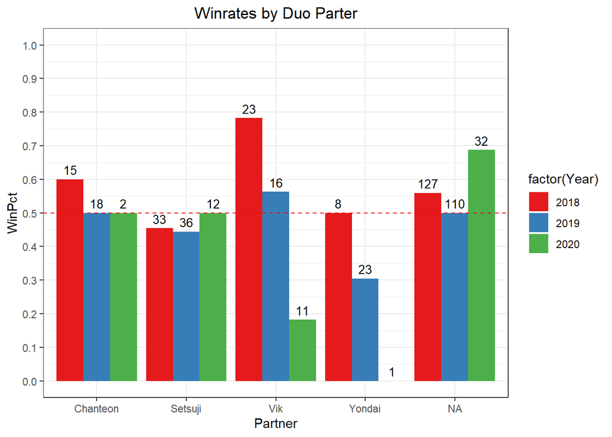

```r
#Plot Winrates by Partner
ddd <- data.frame(dat)

ggplot(data=ddd, aes(x=Partner, y=WinPct, fill=factor(Year))) +
  geom_bar(stat="identity", position=position_dodge()) +
  geom_text(aes(label=n), vjust=-.5, color="black", size=3.5, position = position_dodge(0.9))+
  scale_fill_brewer(palette = "Set1") +
  scale_y_continuous(limits = c(0:1), breaks = seq(0,1,.1)) +
  geom_hline(yintercept = .5, linetype = "dashed", color = "red") +
  theme_bw() +
  ggtitle("Winrates by Duo Parter") +
  theme(plot.title = element_text(hjust = 0.5))
```

My winrates with Chanteon and Solo (NA) are the only ones that are at or above 50% for all three years.

## Winrates by Month

Now, let’s investigate if the time of the year has any impact on my winrates.

```r
#2018
bymonth18 <- dat18 %>%
  group_by(Month) %>%
  summarise(KDA=sum(Kills + Assists)/sum(Deaths), Wins=sum(Win1),WinPct=sum(Win1)/n(),n=n()) %>%
  mutate(Year = 2018) %>%
  arrange(desc(WinPct))

#2019
bymonth19 <- dat19 %>%
  group_by(Month) %>%
  summarise(KDA=sum(Kills + Assists)/sum(Deaths), Wins=sum(Win1),WinPct=sum(Win1)/n(),n=n()) %>%
  mutate(Year = 2019) %>%
  arrange(desc(WinPct))

#2020
bymonth20 <- dat20 %>%
  group_by(Month) %>%
  summarise(KDA=sum(Kills + Assists)/sum(Deaths), Wins=sum(Win1),WinPct=sum(Win1)/n(),n=n()) %>%
  mutate(Year = 2020) %>%
  arrange(desc(WinPct))
bymonth18
```

```
## # A tibble: 10 x 6
##    Month       KDA  Wins WinPct     n  Year
##    <chr>     <dbl> <dbl>  <dbl> <int> <dbl>
##  1 February   4.38     7  0.778     9  2018
##  2 June       4.36    19  0.633    30  2018
##  3 October    2.43     8  0.615    13  2018
##  4 April      8.16     6  0.6      10  2018
##  5 May        3.64    18  0.6      30  2018
##  6 August     3.63    17  0.548    31  2018
##  7 July       3.47    20  0.541    37  2018
##  8 September  3.06     8  0.533    15  2018
##  9 January    4.17     9  0.529    17  2018
## 10 March      3.19     5  0.357    14  2018
```

```r
bymonth19
```

```
## # A tibble: 11 x 6
##    Month       KDA  Wins WinPct     n  Year
##    <chr>     <dbl> <dbl>  <dbl> <int> <dbl>
##  1 November   3        1  1         1  2019
##  2 October    2.22     2  0.667     3  2019
##  3 August     3       15  0.6      25  2019
##  4 April      2.93    11  0.579    19  2019
##  5 May        2.82    21  0.568    37  2019
##  6 September  2.51    16  0.552    29  2019
##  7 January    2.40     5  0.385    13  2019
##  8 June       2.53    13  0.351    37  2019
##  9 February   2.34     7  0.35     20  2019
## 10 July       4.08     1  0.333     3  2019
## 11 March      2.4      4  0.25     16  2019
```

```r
bymonth20
```

```
## # A tibble: 4 x 6
##   Month      KDA  Wins WinPct     n  Year
##   <chr>    <dbl> <dbl>  <dbl> <int> <dbl>
## 1 February  3.65    10  0.588    17  2020
## 2 March     3.71    11  0.579    19  2020
## 3 April     3.15     9  0.562    16  2020
## 4 January   2.17     1  0.167     6  2020
```

```r
#Combined
dat_month <- rbind(bymonth18, bymonth19, bymonth20)
dat_month <- tibble(dat_month)
x2 <- dat_month %>%
  mutate("Losses" = n - Wins)
x2 <- x2 %>%
  group_by(Month) %>%
  summarise(Wins=sum(Wins), Losses=sum(Losses))
x2 <- x2 %>%
  mutate("WinPct" = Wins / (Wins + Losses))
x2
```

```
## # A tibble: 11 x 4
##    Month      Wins Losses WinPct
##    <chr>     <dbl>  <dbl>  <dbl>
##  1 April        26     19  0.578
##  2 August       32     24  0.571
##  3 February     24     22  0.522
##  4 January      15     21  0.417
##  5 July         21     19  0.525
##  6 June         32     35  0.478
##  7 March        20     29  0.408
##  8 May          39     28  0.582
##  9 November      1      0  1
## 10 October      10      6  0.625
## 11 September    24     20  0.545
```

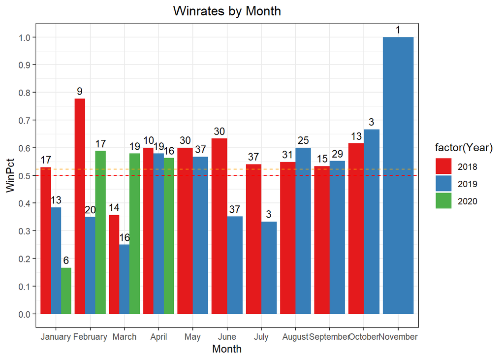

```r
#Plot Winrates by Month
ddd2 <- data.frame(dat_month)
ddd2$Month <- factor(ddd2$Month,levels = c("January", "February", "March", "April","May","June","July","August","September","October","November"))
overallwinrate <- sum(ddd$Wins)/sum(ddd$n)

ggplot(data=ddd2, aes(x=Month, y=WinPct, fill=factor(Year))) +
  geom_bar(stat="identity", position=position_dodge()) +
  geom_text(aes(label=n), vjust=-.5, color="black", size=3.5, position = position_dodge(0.9))+
  scale_fill_brewer(palette = "Set1") +
  scale_y_continuous(limits = c(0:1), breaks = seq(0,1,.1)) +
  geom_hline(yintercept = .5, linetype = "dashed", color = "red") +
  geom_hline(yintercept = overallwinrate, linetype = "dashed", color = "orange") +
  theme_bw() +
  ggtitle("Winrates by Month") +
  theme(plot.title = element_text(hjust = 0.5))
```

Historically, April and May have been good months fror my winrates. I also seem to play well later on in the year, though the number of games played are also on the lower end.

```r
#How Often Do I Get My Main Role
#2018
a1 <- length(which(dat18$Primary == dat18$Role))
b1 <- length(which(dat18$Secondary == dat18$Role))
a1 / nrow(dat18)
```

```
## [1] 0.9708738
```

```r
b1 / nrow(dat18)
```

```
## [1] 0.01941748
```

For the most part, I get my Primary role.

```r
#What Is My Winrate By Role
#2018
#Primary
a2 <- which(dat18$Role == dat18$Primary)
mean(dat18[a2,]$Win1)
```

```
## [1] 0.565
```

```r
#Secondary
b2 <- which(dat18$Role == dat18$Secondary)
mean(dat18[b2,]$Win1)
```

```
## [1] 0.75
```

```r
#Jungle
jg <- which(dat18$Role == "JNG")
mean(dat18[jg,]$Win1)
```

```
## [1] 0.5692308
```

```r
#Support
sup <- which(dat18$Role == "SUP")
mean(dat18[sup,]$Win1)
```

```
## [1] 0.4444444
```

```r
#ADC
adc <- which(dat18$Role == "ADC")
mean(dat18[adc,]$Win1)
```

```
## [1] 1
```

In 2018, my winrate on my Secondary role was an incredible 75%, however on a much smaller sample size. I also played better as a Jungler compared to Support. As ADC, I won every game but only played a few on that position.

```r
#2019
#Primary
a22 <- which(dat19$Role == dat19$Primary)
mean(dat19[a22,]$Win1)
```

```
## [1] 0.4795918
```

```r
#Secondary
b22 <- which(dat19$Role == dat19$Secondary)
mean(dat19[b22,]$Win1)
```

```
## [1] 0
```

```r
#Jungle
jg2 <- which(dat19$Role == "JNG")
mean(dat19[jg2,]$Win1)
```

```
## [1] 0.4487179
```

```r
#Support
sup2 <- which(dat19$Role == "SUP")
mean(dat19[sup2,]$Win1)
```

```
## [1] 0.5714286
```

```r
#ADC
adc2 <- which(dat19$Role == "ADC")
mean(dat19[adc2,]$Win1)
```

```
## [1] 0.5
```

```r
#MID
mid2 <- which(dat19$Role == "MID")
mean(dat19[mid2,]$Win1)
```

```
## [1] 0
```

2019 was the opposite from 2018 as I won more games as Support and had a below 50% winrate as a Jungler.

```r
#2020
#Primary
a3 <- which(dat20$Role == dat20$Primary)
mean(dat20[a3,]$Win1)
```

```
## [1] 0.5185185
```

```r
#Secondary
b3 <- which(dat20$Role == dat20$Second)
mean(dat20[b3,]$Win1)
```

```
## [1] 0.75
```

```r
#Jungle
jg3 <- which(dat20$Role == "JNG")
mean(dat20[jg3,]$Win1)
```

```
## [1] 0.5357143
```

```r
#Support
sup3 <- which(dat20$Role == "SUP")
mean(dat20[sup3,]$Win1)
```

```
## [1] 0.5
```

```r
#Overall
dat18_2 <- dat18 %>%
  select(Primary, Secondary, Role, Win1)
dat19_2 <- dat19 %>%
  select(Primary, Secondary, Role, Win1)
dat20_2 <- dat20 %>%
  select(Primary, Second, Role, Win1) %>%
  rename(Secondary = Second)
tot <- rbind(dat18_2, dat19_2, dat20_2)

#Primary
a4 <- which(tot$Role == tot$Primary)
mean(tot[a4,]$Win1)
```

```
## [1] 0.5222222
```

```r
#Secondary
b4 <- which(tot$Role == tot$Secondary)
mean(tot[b4,]$Win1)
```

```
## [1] 0.5454545
```

```r
#Jungle
jg4 <- which(tot$Role == "JNG")
mean(tot[jg4,]$Win1)
```

```
## [1] 0.5184275
```

```r
#Support
sup4 <- which(tot$Role == "SUP")
mean(tot[sup4,]$Win1)
```

```
## [1] 0.5471698
```

```r
#Mid
mid4 <- which(tot$Role == "MID")
mean(tot[mid4,]$Win1)
```

```
## [1] 0
```

```r
#ADC
adc4 <- which(tot$Role == "ADC")
mean(tot[adc4,]$Win1)
```

```
## [1] 0.6666667
```

## Champion Analysis

How well do I play on various champions?

```r
#Filter By Champion
#2018
mod18 <- dat18 %>%
  group_by(Champion) %>%
  summarise(KDA = round(((sum(Kills) + sum(Assists))/sum(Deaths)),3), Count = n(), WinPct = round(sum(Win1)/(sum(Win1) + sum(Loss1)),3)) %>%
  arrange(desc(WinPct, KDA))
mod18
```

```
## # A tibble: 16 x 4
##    Champion         KDA Count WinPct
##    <chr>          <dbl> <int>  <dbl>
##  1 Miss Fortune   1.67      1  1
##  2 Nunu & Willump 4         3  1
##  3 Ziggs          2.67      1  1
##  4 Jarvan IV      4.43     24  0.708
##  5 Blitzcrank     5.29      3  0.667
##  6 Trundle        3.78    114  0.596
##  7 Gragas         2.76     11  0.545
##  8 Zac            5.87     27  0.519
##  9 Nautilus       3.09      5  0.4
## 10 Graves         2.38      6  0.333
## 11 Kha'Zix        3         4  0.25
## 12 Evelynn        0.455     1  0
## 13 Kindred        1.2       1  0
## 14 Shyvana        1.31      3  0
## 15 Tahm Kench     1         1  0
## 16 Xin Zhao       1.14      1  0
```

```r
#2019
mod19 <- dat19 %>%
  group_by(Champion) %>%
  summarise(KDA = round(((sum(Kills) + sum(Assists))/sum(Deaths)),3), Count = n(), WinPct = round(sum(Win1)/(sum(Win1) + sum(Loss1)),3)) %>%
  arrange(desc(WinPct, KDA))
mod19
```

```
## # A tibble: 18 x 4
##    Champion     KDA Count WinPct
##    <chr>      <dbl> <int>  <dbl>
##  1 Blitzcrank  3.27     2  1
##  2 Dr. Mundo   3.44     2  1
##  3 Nocturne    2.69     7  0.714
##  4 Ezreal      3.95     3  0.667
##  5 Leona       2.5      9  0.556
##  6 Nautilus    2.98    32  0.531
##  7 Sejuani     2.82    31  0.516
##  8 Jarvan IV   2.82    38  0.474
##  9 Elise       2.49    17  0.471
## 10 Rek'Sai     2.03    11  0.455
## 11 Trundle     2.31    11  0.455
## 12 Kha'Zix     2.17     5  0.4
## 13 Gragas      2.29     6  0.333
## 14 Xin Zhao    2.22    13  0.308
## 15 Zac         3.37     7  0.286
## 16 Hecarim     1.48     7  0.143
## 17 Lissandra   1.67     1  0
## 18 Sivir       2.86     1  0
```

```r
#2020
mod20 <- dat20 %>%
  group_by(Champion) %>%
  summarise(KDA = round(((sum(Kills) + sum(Assists))/sum(Deaths)),3), Count = n(), WinPct = round(sum(Win1)/(sum(Win1) + sum(Loss1)),3)) %>%
  arrange(desc(WinPct, KDA))
mod20
```

```
## # A tibble: 7 x 4
##   Champion    KDA Count WinPct
##   <chr>     <dbl> <int>  <dbl>
## 1 Rek'Sai    1.6      1  1
## 2 Zac        5.20    21  0.667
## 3 Nautilus   4.61     5  0.6
## 4 Trundle    2.58    10  0.6
## 5 Elise      2.78    11  0.364
## 6 Sejuani    2.24     9  0.333
## 7 Jarvan IV  0.7      1  0
```

### Personal Performance by Champion

Sorting Champions by the number of times I recorded each grade.

```r
#2018
library(reshape2)
m18 <- dat18 %>%
  select(Champion, Grade) %>%
  group_by(Champion) %>%
  mutate(Count = n()) %>%
  arrange(desc(Count))

m18$Grade <- factor(m18$Grade,levels = c("S+","S","S-","A+","A","A-","B+","B","B-","C+","C","C-"))

dcast(m18, Champion~Grade, fun.aggregate = length)
```

```
##          Champion S+ S S- A+  A A- B+ B B- C+ C C- NA
## 1      Blitzcrank  0 0  1  0  1  0  0 0  0  1 0  0  0
## 2         Evelynn  0 0  0  0  0  0  0 0  0  1 0  0  0
## 3          Gragas  0 1  1  1  1  3  1 1  1  0 1  0  0
## 4          Graves  0 1  0  0  0  0  0 2  2  0 0  1  0
## 5       Jarvan IV  0 0  2  7  2  2  4 1  0  0 0  0  6
## 6         Kha'Zix  0 0  1  1  1  0  1 0  0  0 0  0  0
## 7         Kindred  0 0  0  0  0  0  0 1  0  0 0  0  0
## 8    Miss Fortune  0 0  0  0  0  0  1 0  0  0 0  0  0
## 9        Nautilus  1 1  0  0  0  0  1 0  0  2 0  0  0
## 10 Nunu & Willump  0 0  2  0  1  0  0 0  0  0 0  0  0
## 11        Shyvana  0 0  0  0  0  0  0 0  1  0 0  0  2
## 12     Tahm Kench  0 0  0  0  0  0  0 0  0  1 0  0  0
## 13        Trundle  3 8 20 26 17 11  9 5 10  4 1  0  0
## 14       Xin Zhao  0 0  0  0  0  0  0 1  0  0 0  0  0
## 15            Zac  4 3  7  3  0  4  5 1  0  0 0  0  0
## 16          Ziggs  0 0  0  1  0  0  0 0  0  0 0  0  0
```

```r
#2019
m19 <- dat19 %>%
  select(Champion, Grade) %>%
  group_by(Champion) %>%
  mutate(Count = n()) %>%
  arrange(desc(Count))

m19$Grade <- factor(m19$Grade,levels = c("S+","S","S-","A+","A","A-","B+","B","B-","C+","C","C-"))

dcast(m19, Champion~Grade, fun.aggregate = length)
```

```
##      Champion S+ S S- A+ A A- B+ B B- C+ C C-
## 1  Blitzcrank  0 1  0  0 1  0  0 0  0  0 0  0
## 2   Dr. Mundo  0 0  1  0 0  1  0 0  0  0 0  0
## 3       Elise  0 3  1  1 4  0  4 3  1  0 0  0
## 4      Ezreal  0 0  2  0 0  1  0 0  0  0 0  0
## 5      Gragas  0 0  0  2 0  1  0 1  1  1 0  0
## 6     Hecarim  0 0  0  1 0  1  0 1  1  3 0  0
## 7   Jarvan IV  0 4  3  3 5  2  4 8  2  4 2  1
## 8     Kha'Zix  0 1  0  0 1  1  0 0  1  1 0  0
## 9       Leona  0 1  1  0 2  1  1 0  0  2 0  1
## 10  Lissandra  0 0  0  0 0  0  0 0  1  0 0  0
## 11   Nautilus  1 4  2  4 3  3  3 5  2  2 1  2
## 12   Nocturne  0 0  2  1 0  1  1 0  0  2 0  0
## 13    Rek'Sai  0 0  2  0 0  1  2 0  0  4 2  0
## 14    Sejuani  1 1  4  2 2  5  4 6  3  2 1  0
## 15      Sivir  0 0  0  1 0  0  0 0  0  0 0  0
## 16    Trundle  0 0  0  4 1  2  0 1  2  0 1  0
## 17   Xin Zhao  0 1  2  2 0  1  0 2  3  2 0  0
## 18        Zac  0 0  0  1 1  2  1 2  0  0 0  0
```

```r
#2020
m20 <- dat20 %>%
  select(Champion, Grade) %>%
  group_by(Champion) %>%
  mutate(Count = n()) %>%
  arrange(desc(Count))

m20$Grade <- factor(m20$Grade,levels = c("S+","S","S-","A+","A","A-","B+","B","B-","C+","C","C-"))
m20$Champion <- factor(m20$Champion, levels = c("Zac","Elise",  "Trundle" ,  "Sejuani" ,  "Nautilus","Jarvan IV", "Rek'Sai" ))

dcast(m20, Champion~Grade, fun.aggregate = length)
```

```
##    Champion S+ S S- A+ A A- B+ B B- C+ C
## 1       Zac  0 6  2  4 2  3  4 0  0  0 0
## 2     Elise  1 1  0  3 1  1  1 2  1  0 0
## 3   Trundle  1 0  2  1 2  0  0 2  1  1 0
## 4   Sejuani  0 2  1  0 1  0  0 1  2  1 1
## 5  Nautilus  1 2  0  0 0  0  0 0  1  1 0
## 6 Jarvan IV  0 0  0  0 0  0  0 0  1  0 0
## 7   Rek'Sai  0 0  0  0 0  1  0 0  0  0 0
```

Sorting Champions by the number of times I recorded each rank with 1 being the best.

```r
#Personal
#2019
mm19 <- dat19 %>%
  select(Champion, `My Rank`) %>%
  group_by(Champion) %>%
  mutate(Count = n()) %>%
  arrange(desc(Count))

dcast(mm19, Champion~`My Rank`, fun.aggregate = length)
```

```
##      Champion  1 2 3 4 5 6 7 8 9 10
## 1  Blitzcrank  0 1 1 0 0 0 0 0 0  0
## 2   Dr. Mundo  0 1 1 0 0 0 0 0 0  0
## 3       Elise  3 0 4 3 4 0 0 1 2  0
## 4      Ezreal  0 0 2 0 0 0 0 0 1  0
## 5      Gragas  0 1 1 1 0 1 0 1 1  0
## 6     Hecarim  1 1 0 0 2 1 0 1 1  0
## 7   Jarvan IV  8 6 4 6 4 7 3 0 0  0
## 8     Kha'Zix  1 0 1 0 1 1 1 0 0  0
## 9       Leona  1 2 1 1 1 1 2 0 0  0
## 10  Lissandra  0 0 0 0 0 0 0 0 1  0
## 11   Nautilus 12 3 5 2 1 7 0 0 1  1
## 12   Nocturne  1 2 1 0 2 0 1 0 0  0
## 13    Rek'Sai  2 0 0 0 4 0 3 1 1  0
## 14    Sejuani  8 3 5 3 5 6 0 0 0  1
## 15      Sivir  0 0 1 0 0 0 0 0 0  0
## 16    Trundle  1 1 1 2 1 5 0 0 0  0
## 17   Xin Zhao  3 1 1 0 0 5 1 2 0  0
## 18        Zac  2 0 2 1 2 0 0 0 0  0
```

```r
mm19 %>%
  group_by(Champion) %>%
  summarise(AvgRank = mean(`My Rank`), Count = n()) %>%
  arrange(AvgRank)
```

```
## # A tibble: 18 x 3
##    Champion   AvgRank Count
##    <chr>        <dbl> <int>
##  1 Blitzcrank    2.5      2
##  2 Dr. Mundo     2.5      2
##  3 Sivir         3        1
##  4 Zac           3.14     7
##  5 Nautilus      3.34    32
##  6 Nocturne      3.57     7
##  7 Sejuani       3.61    31
##  8 Jarvan IV     3.66    38
##  9 Leona         4.11     9
## 10 Elise         4.29    17
## 11 Kha'Zix       4.4      5
## 12 Trundle       4.45    11
## 13 Xin Zhao      4.69    13
## 14 Ezreal        5        3
## 15 Hecarim       5.14     7
## 16 Gragas        5.33     6
## 17 Rek'Sai       5.45    11
## 18 Lissandra     9        1
```

```r
#2020
mm20 <- dat20 %>%
  select(Champion, `My Rank`) %>%
  group_by(Champion) %>%
  mutate(Count = n()) %>%
  arrange(desc(Count))

dcast(mm20, Champion~`My Rank`, fun.aggregate = length)
```

```
##    Champion  1 2 3 4 5 6 7 8 9 10
## 1     Elise  2 0 3 2 1 1 1 1 0  0
## 2 Jarvan IV  0 0 0 0 0 0 0 0 0  1
## 3  Nautilus  1 0 2 0 1 1 0 0 0  0
## 4   Rek'Sai  0 0 0 0 0 1 0 0 0  0
## 5   Sejuani  4 0 0 2 1 1 1 0 0  0
## 6   Trundle  4 1 1 0 1 0 2 0 1  0
## 7       Zac 10 4 2 2 3 0 0 0 0  0
```

```r
mm20 %>%
  group_by(Champion) %>%
  summarise(AvgRank = mean(`My Rank`), Count = n()) %>%
  arrange(AvgRank)
```

```
## # A tibble: 7 x 3
##   Champion  AvgRank Count
##   <chr>       <dbl> <int>
## 1 Zac          2.24    21
## 2 Sejuani      3.33     9
## 3 Nautilus     3.6      5
## 4 Trundle      3.7     10
## 5 Elise        4.09    11
## 6 Rek'Sai      6        1
## 7 Jarvan IV   10        1
```

```r
dat20 %>%
  select(Champion, `Team Rank`) %>%
  group_by(Champion) %>%
  summarise(AvgTeamRank = mean(`Team Rank`), Count = n()) %>%
  arrange(AvgTeamRank)
```

```
## # A tibble: 7 x 3
##   Champion  AvgTeamRank Count
##   <chr>           <dbl> <int>
## 1 Sejuani          1.22     9
## 2 Zac              1.29    21
## 3 Elise            1.73    11
## 4 Trundle          1.8     10
## 5 Nautilus         2        5
## 6 Rek'Sai          4        1
## 7 Jarvan IV        5        1
```

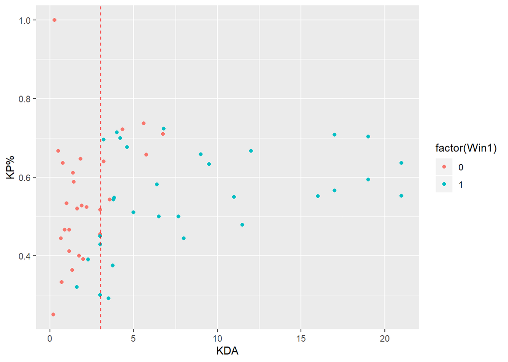

```r
#Plot KP vs KDA
ggplot(data = dat20, aes(x = KDA, y = `KP%`, color=factor(Win1))) +
  geom_point() +
  geom_vline(xintercept = 3, linetype = "dashed", color = "red")
```

For the most part, if I have a KDA of 3 works as a simple cluster barrier to determine if I win the game or not.

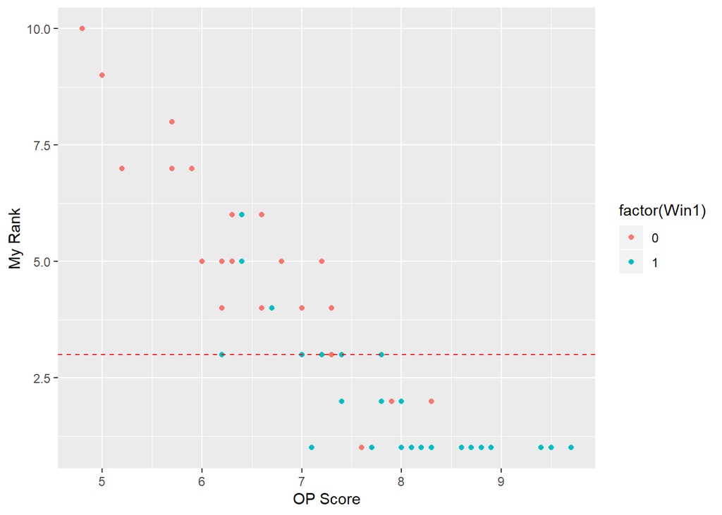

```r
#Plot OP Score vs KDA
ggplot(data = dat20, aes(x = `OP Score`, y = `My Rank`, color=factor(Win1))) +
  geom_point() +
  geom_hline(yintercept = 3, linetype = "dashed", color = "red")
```

Out of the 10 people in the game, if I rank #3 or higher, I will most likely win the game.